# Which Storm Types Are The Most Harmful?

Steffen Hartleib

May 18, 2015

## Summary

To identify the storms that cause the most health and economic damage I analzyed a data set from U.S. National Oceanic and Atmospheric Administration’s (NOAA) storm database. The data tracks major storm events in the United States, including when and where they occur, as well as estimates of any fatalities, injuries, and property damage.  
I used the fatalities as a measure of health impact and the sum of crop and property damage as as the measure of economic impact.

15 Storm events caused 80% of the Fatalities while 7 Storm events caused 80% of the economic damge. Tornados and Flash Floods are in the top three of both lists.

## Processing

I reduced the data set to the five relevant columns: Event Type, Beginning Date, Fatalities, Property Damage, and Crop damage. I also add a “Year” column to make it easier to track events and their impact over time.

```r
require(dplyr)
require(reshape2)
require(ggplot2)
options(scipen=999)
storm <- read.csv(bzfile("repdata-data-StormData.csv.bz2"))
storm <- select(storm,EVTYPE,BGN_DATE,FATALITIES,CROPDMG,PROPDMG)
storm$BGN_DATE <- as.Date(storm$BGN_DATE, format = "%m/%d/%Y %H:%M:%S")
storm <- mutate(storm, Year = as.POSIXlt(storm$BGN_DATE)$year  + 1900)
```

#### Figure 1

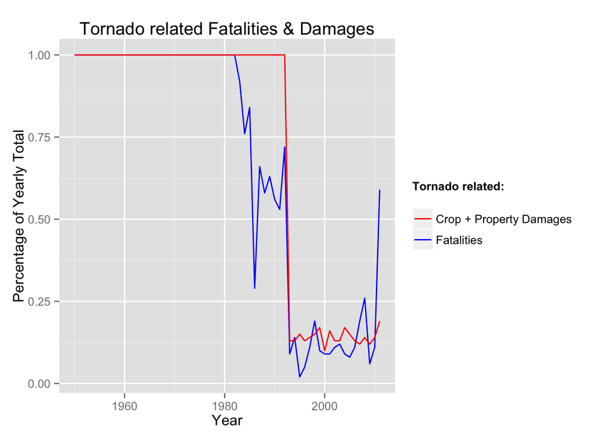

```r
# Tornado related fataltities and damages per year
TorFatDamYear <- filter(storm, storm$EVTYPE == "TORNADO")
TorFatDamYear <- group_by(TorFatDamYear, Year)
TorFatDamYear <- summarize(TorFatDamYear,
                        TorFat = sum(FATALITIES),
                        TorDam = sum(CROPDMG + PROPDMG))
# Total fatalites and damages per year
TotFatDamYear <- group_by(storm, Year)
TotFatDamYear <- summarize(TotFatDamYear,
                        TotFat = sum(FATALITIES),
                        TotDam = sum(CROPDMG + PROPDMG))
# Damagas and fatalities as percentage of yearly totals
TorVsTotYear <- data.frame(TotFatDamYear, TorFatDamYear[,-1])
TorVsTotYear <- mutate(TorVsTotYear, TornFatVsTot = round(TorFat/TotFat,2),
                        TornDamVsTot = round(TorDam/TotDam,2))
TorVsTotYear <- select(TorVsTotYear, Year, TornFatVsTot, TornDamVsTot)

ggplot(TorVsTotYear, aes(Year)) +
                     geom_line(aes(y = TornFatVsTot, colour = "TornFatVsTot")) +
                     geom_line(aes(y = TornDamVsTot, color = "TornDamVsTot")) +
                     labs(title = "Tornado related Fatalities & Damages", x = "Year",
                     y = "Percentage of Yearly Total" ) + scale_color_manual("Tornado related:\n", labels = c("Crop + Property Damages","Fatalities"), values = c("red","blue"))
```

## Results

### Health Impact

I used the total number of fatalities per Event Type as the measure of health impact. To answer the question “which storms are the most harmful”, I identified the set of most harmful Event Types that caused 80% of the total damage. The table below shows Event Types ranked by total Fatalities, along with a column showing for each Event Type the percentage of Total Fatalities, and the cumulative percentage of Total Fatalities. It turns out that 80% of the fatalties are caused by just 15 Event Types. The results are shown the in the following table.

```r
storm93 <- filter(storm, Year > 1992)
FatTot <- sum(storm93$FATALITIES)
HealthImpact <- select(storm93, EVTYPE,FATALITIES) %>%
        group_by(EVTYPE) %>%
        summarise(TotFat = sum(FATALITIES),FatPercOfTotFat = round(sum(FATALITIES)/FatTot,2)) %>%
        arrange(- TotFat) %>%
        mutate(CumeFatPercTotFat = cumsum(FatPercOfTotFat)) %>%
        filter(CumeFatPercTotFat <= .8)
colnames(HealthImpact) <- c("StormType", "Fatalities", "FatalitiesPercofTotal", "CumeFatalitiesPerc")
HealthImpact
```

```
## Source: local data frame [15 x 4]
##
##            StormType Fatalities FatalitiesPercofTotal CumeFatalitiesPerc
## 1     EXCESSIVE HEAT       1903                  0.18               0.18
## 2            TORNADO       1621                  0.15               0.33
## 3        FLASH FLOOD        978                  0.09               0.42
## 4               HEAT        937                  0.09               0.51
## 5          LIGHTNING        816                  0.08               0.59
## 6              FLOOD        470                  0.04               0.63
## 7        RIP CURRENT        368                  0.03               0.66
## 8          HIGH WIND        248                  0.02               0.68
## 9          TSTM WIND        241                  0.02               0.70
## 10         AVALANCHE        224                  0.02               0.72
## 11      WINTER STORM        206                  0.02               0.74
## 12      RIP CURRENTS        204                  0.02               0.76
## 13         HEAT WAVE        172                  0.02               0.78
## 14      EXTREME COLD        160                  0.01               0.79
## 15 THUNDERSTORM WIND        133                  0.01               0.80
```

#### Figure 2

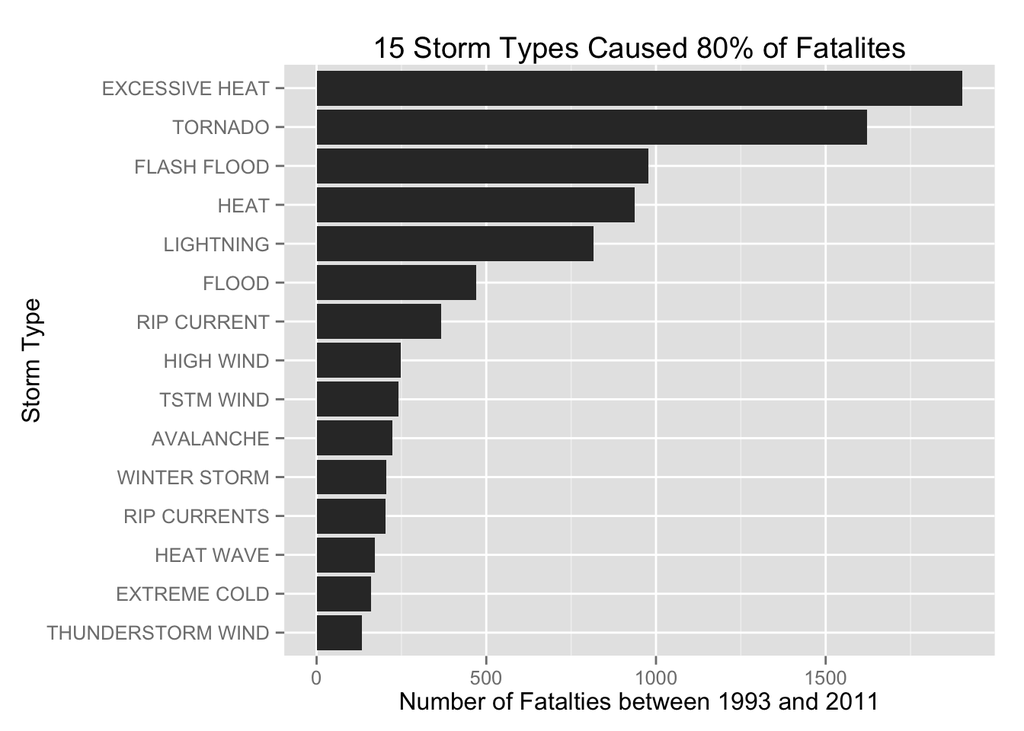

```r
HealthImpact$StormType <- reorder(HealthImpact$StormType, HealthImpact$Fatalities)
ggplot(HealthImpact, aes(x = StormType, y = Fatalities)) + geom_bar(stat = "Identity") + coord_flip() + labs(title = "15 Storm Types Caused 80% of Fatalites", y = "Number of Fatalties between 1993 and 2011", x = "Storm Type")
```

### Ecomonic Impact

```r
DamTot <- sum(storm93$CROPDMG + storm93$PROPDMG)
EconImpact <- select(storm93, EVTYPE,CROPDMG,PROPDMG) %>%
group_by(EVTYPE) %>%
summarise( TotDam = round(sum(CROPDMG +PROPDMG),0),
           DamPercOfTotDam = round(sum(CROPDMG +PROPDMG)/DamTot,2)) %>%
arrange(- TotDam) %>%
mutate(CumeDamPercTotDam = cumsum(DamPercOfTotDam))%>%
filter(CumeDamPercTotDam <= .81)
colnames(EconImpact) <- c("StormType","Damage", "DamagePercTotal", "CumeDamagePerc")
EconImpact
```

```
## Source: local data frame [7 x 4]
##
##           StormType  Damage DamagePercTotal CumeDamagePerc
## 1       FLASH FLOOD 1599325            0.15           0.15
## 2           TORNADO 1487776            0.14           0.29
## 3         TSTM WIND 1445168            0.14           0.43
## 4              HAIL 1268290            0.12           0.55
## 5             FLOOD 1067976            0.10           0.65
## 6 THUNDERSTORM WIND  943636            0.09           0.74
## 7         LIGHTNING  606932            0.06           0.80
```

#### Figure 3

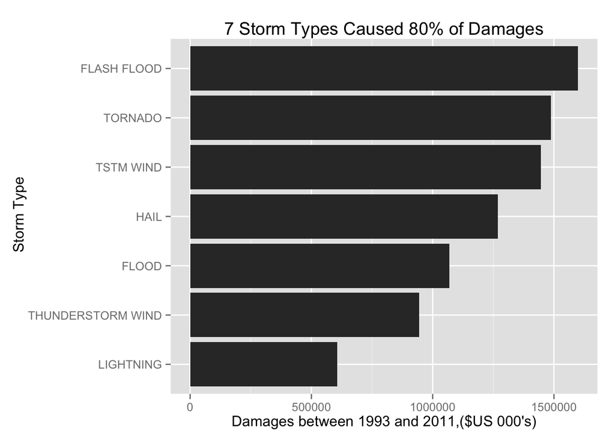

```r
EconImpact$StormType <- reorder(EconImpact$StormType, EconImpact$Damage)
ggplot(EconImpact, aes(x = StormType, y = Damage)) + geom_bar(stat = "Identity") + coord_flip() + labs(title = "7 Storm Types Caused 80% of Damages", y = "Damages between 1993 and 2011,($US 000's)", x = " Storm Type")
```